# Data Process

Home

Data Process

Statistical Model

Machine Learning Model

Conclusion

The dataframe that we will use in the statistical modeling contains writer id, character type, image label, and pixel information about each image.

|  | writer_id | char_type | label | pixel_0 | pixel_1 | pixel_2 | pixel_3 | pixel_4 | pixel_5 | pixel_6 | ... | pixel_16374 | pixel_16375 | pixel_16376 | pixel_16377 | pixel_16378 | pixel_16379 | pixel_16380 | pixel_16381 | pixel_16382 | pixel_16383 |
| --- | --- | --- | --- | --- | --- | --- | --- | --- | --- | --- | --- | --- | --- | --- | --- | --- | --- | --- | --- | --- | --- |
| 0 | 0 | c | W | 0 | 0 | 0 | 0 | 0 | 0 | 0 | ... | 0 | 0 | 0 | 0 | 0 | 0 | 0 | 0 | 0 | 0 |
| 1 | 0 | c | e | 0 | 0 | 0 | 0 | 0 | 0 | 0 | ... | 0 | 0 | 0 | 0 | 0 | 0 | 0 | 0 | 0 | 0 |
| 2 | 0 | c | t | 0 | 0 | 0 | 0 | 0 | 0 | 0 | ... | 0 | 0 | 0 | 0 | 0 | 0 | 0 | 0 | 0 | 0 |
| 3 | 0 | c | h | 0 | 0 | 0 | 0 | 0 | 0 | 0 | ... | 0 | 0 | 0 | 0 | 0 | 0 | 0 | 0 | 0 | 0 |
| 4 | 0 | c | e | 0 | 0 | 0 | 0 | 0 | 0 | 0 | ... | 0 | 0 | 0 | 0 | 0 | 0 | 0 | 0 | 0 | 0 |

5 rows × 16387 columns

Using Lasso we selected the top 17 pixel columns that we will be used in the statistical modeling. These pixel columns are:

```
pixel_4936
pixel_5319
pixel_5448
pixel_5577
pixel_7376
pixel_7503
pixel_7602
pixel_7730
pixel_7858
pixel_8013
pixel_8142
pixel_8495
pixel_10172
pixel_10174
pixel_10177
pixel_10419
pixel_10929
```

We used heatmap to build correlation matrix. It shows that each pixel column that we selected has similar correlation to the writer id. Therefore, we will combine these pixel columns to build a statistical model.

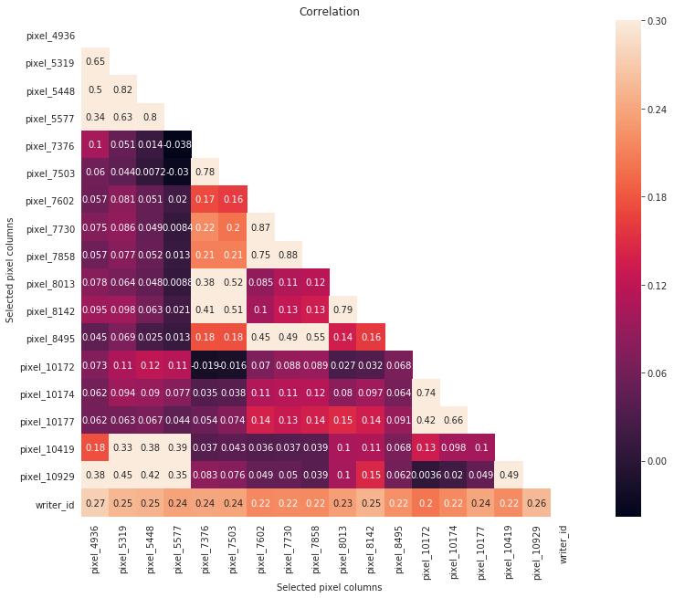

We used multivariable linear regression to model the relationship between pixels of images and the writer. The independent variables are pixel columns that were selected using Lasso, and the dependent variable is the writer id. Below is the summary of the model.

OLS Regression Results

| Dep. Variable: | writer_id | R-squared: | 0.260 |
| --- | --- | --- | --- |
| Model: | OLS | Adj. R-squared: | 0.254 |
| Method: | Least Squares | F-statistic: | 39.16 |
| Date: | Tue, 12 Mar 2019 | Prob (F-statistic): | 8.65e-111 |
| Time: | 13:53:19 | Log-Likelihood: | -3025.1 |
| No. Observations: | 1911 | AIC: | 6086. |
| Df Residuals: | 1893 | BIC: | 6186. |
| Df Model: | 17 |  |  |
| Covariance Type: | nonrobust |  |  |

|  | coef | std err | t | P>\|t\| | [0.025 | 0.975] |
| --- | --- | --- | --- | --- | --- | --- |
| Intercept | 1.1216 | 0.043 | 25.920 | 0.000 | 1.037 | 1.206 |
| pixel_4936 | 0.7205 | 0.116 | 6.218 | 0.000 | 0.493 | 0.948 |
| pixel_5319 | -0.2065 | 0.143 | -1.442 | 0.150 | -0.487 | 0.074 |
| pixel_5448 | 0.0111 | 0.158 | 0.070 | 0.944 | -0.298 | 0.321 |
| pixel_5577 | 0.4846 | 0.115 | 4.204 | 0.000 | 0.259 | 0.711 |
| pixel_7376 | 0.3427 | 0.113 | 3.044 | 0.002 | 0.122 | 0.564 |
| pixel_7503 | 0.1512 | 0.114 | 1.330 | 0.184 | -0.072 | 0.374 |
| pixel_7602 | 0.2991 | 0.124 | 2.403 | 0.016 | 0.055 | 0.543 |
| pixel_7730 | -0.0715 | 0.168 | -0.427 | 0.670 | -0.400 | 0.257 |
| pixel_7858 | 0.0742 | 0.127 | 0.583 | 0.560 | -0.176 | 0.324 |
| pixel_8013 | 0.1562 | 0.105 | 1.491 | 0.136 | -0.049 | 0.362 |
| pixel_8142 | 0.2255 | 0.109 | 2.072 | 0.038 | 0.012 | 0.439 |
| pixel_8495 | 0.3270 | 0.078 | 4.177 | 0.000 | 0.173 | 0.481 |
| pixel_10172 | 0.3086 | 0.087 | 3.552 | 0.000 | 0.138 | 0.479 |
| pixel_10174 | 0.0036 | 0.104 | 0.034 | 0.973 | -0.201 | 0.208 |
| pixel_10177 | 0.3818 | 0.083 | 4.604 | 0.000 | 0.219 | 0.544 |
| pixel_10419 | 0.1441 | 0.075 | 1.933 | 0.053 | -0.002 | 0.290 |
| pixel_10929 | 0.3875 | 0.095 | 4.082 | 0.000 | 0.201 | 0.574 |

| Omnibus: | 24.134 | Durbin-Watson: | 0.447 |
| --- | --- | --- | --- |
| Prob(Omnibus): | 0.000 | Jarque-Bera (JB): | 20.854 |
| Skew: | 0.196 | Prob(JB): | 2.96e-05 |
| Kurtosis: | 2.670 | Cond. No. | 12.0 |

Warnings:  
[1] Standard Errors assume that the covariance matrix of the errors is correctly specified.

We can see that the R-squared is 26%, which means the model only explains 26% variability of the response variable. Low R-squared value indicates that the model does not fit the data well. By looking at the p-value for each independent variable, we can see that `pixel_5319`, `pixel_5448`, `pixel_7503`, `pixel_7730`, `pixel_7858`, `pixel_8013`, `pixel_10174` and `pixel_10419` are not statistically significant since their p-value are greater than alpha level 0.05, which means the model does not gain enough information from having these variables.

**The accuracy score of this linear model is:**

```
0.34798534798534797
```

This plot compares the actual writer id and the predicted writer id. We can see that the model only predictes some of writers correctly.

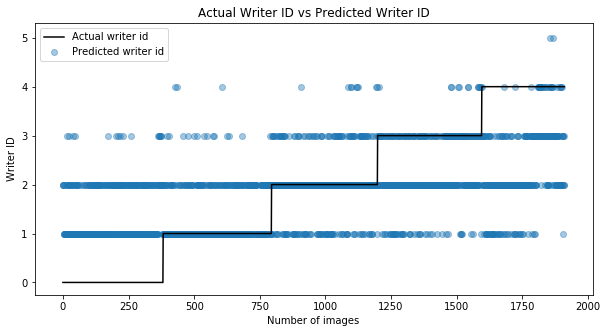

The residual plot below shows more details on the pattern of the predicted values. The horizontal line indicates that the predicted writer id matches the actual writer id. We can see that linear regression model is not a good choice to estiamte the classification outcome because it predicted the writer id wrong most of the time.

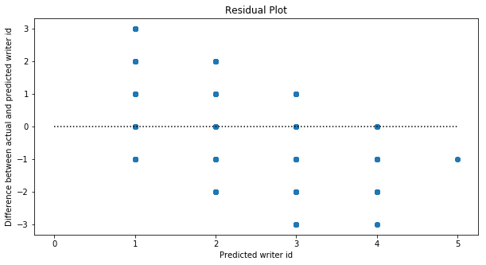